# Track_records_visualisation

Joseph Bolton

17 February 2019

Here is the dataset, printed in full:

```r
track_records_dataset <-
  read.csv( "C:/Users/Joe Bolton/Desktop/sync_to_google_drive/UCT honours work/Multivariate Analysis/data/men.csv") %>%
  select(-Country) %>%
  rename( country = countrylabel) %>%
  mutate( country = as.factor(country) )

table_with_formatting <-
    formattable( track_records_dataset,
                 list(  m100 = color_tile("transparent", "pink"),
                        m200 = color_tile("transparent", "green"),
                        m400 = color_tile("transparent", "blue"),
                        m800 = color_tile("transparent", "orange"),
                        m1500 = color_tile("transparent", "red"),
                        m5000 = color_tile("transparent", "yellow"),
                        m5000 = color_tile("transparent", "purple"),
                        m10000 = color_tile("transparent", "dark grey"),
                        marathon = color_tile("transparent", "violet")
                     )
                )

table_with_formatting
```

| country | m100 | m200 | m400 | m800 | m1500 | m5000 | m10000 | marathon |
| --- | --- | --- | --- | --- | --- | --- | --- | --- |
| Argentina | 10.23 | 20.37 | 46.18 | 1.77 | 3.68 | 13.33 | 27.65 | 129.57 |
| Australia | 9.93 | 20.06 | 44.38 | 1.74 | 3.53 | 12.93 | 27.53 | 127.51 |
| Austria | 10.15 | 20.45 | 45.80 | 1.77 | 3.58 | 13.26 | 27.72 | 132.22 |
| Belgium | 10.14 | 20.19 | 45.02 | 1.73 | 3.57 | 12.83 | 26.87 | 127.20 |
| Bermuda | 10.27 | 20.30 | 45.26 | 1.79 | 3.70 | 14.64 | 30.49 | 146.37 |
| Brazil | 10.00 | 19.89 | 44.29 | 1.70 | 3.57 | 13.48 | 28.13 | 126.05 |
| Canada | 9.84 | 20.17 | 44.72 | 1.75 | 3.53 | 13.23 | 27.60 | 130.09 |
| Chile | 10.10 | 20.15 | 45.92 | 1.76 | 3.65 | 13.39 | 28.09 | 132.19 |
| China | 10.17 | 20.42 | 45.25 | 1.77 | 3.61 | 13.42 | 28.17 | 129.18 |
| Columbia | 10.29 | 20.85 | 45.84 | 1.80 | 3.72 | 13.49 | 27.88 | 131.17 |
| CookIslands | 10.97 | 22.46 | 51.40 | 1.94 | 4.24 | 16.70 | 35.38 | 171.26 |
| CostaRica | 10.32 | 20.96 | 46.42 | 1.87 | 3.84 | 13.75 | 28.81 | 133.23 |
| CzechRepublic | 10.24 | 20.61 | 45.77 | 1.75 | 3.58 | 13.42 | 27.80 | 131.57 |
| Denmark | 10.29 | 20.52 | 45.89 | 1.69 | 3.52 | 13.42 | 27.91 | 129.43 |
| DominicanRepub | 10.16 | 20.65 | 44.90 | 1.81 | 3.73 | 14.31 | 30.43 | 146.00 |
| Finland | 10.21 | 20.47 | 45.49 | 1.74 | 3.61 | 13.27 | 27.52 | 131.15 |
| France | 10.02 | 20.16 | 44.64 | 1.72 | 3.48 | 12.98 | 27.38 | 126.36 |
| Germany | 10.06 | 20.23 | 44.33 | 1.73 | 3.53 | 12.91 | 27.36 | 128.47 |
| GreatBritain | 9.87 | 19.94 | 44.36 | 1.70 | 3.49 | 13.01 | 27.30 | 127.13 |
| Greece | 10.11 | 19.85 | 45.57 | 1.75 | 3.61 | 13.48 | 28.12 | 132.04 |
| Guatemala | 10.32 | 21.09 | 48.44 | 1.82 | 3.74 | 13.98 | 29.34 | 132.53 |
| Hungary | 10.08 | 20.11 | 45.43 | 1.76 | 3.59 | 13.45 | 28.03 | 132.10 |
| India | 10.33 | 20.73 | 45.48 | 1.76 | 3.63 | 13.50 | 28.81 | 132.00 |
| Indonesia | 10.20 | 20.93 | 46.37 | 1.83 | 3.77 | 14.21 | 29.65 | 139.18 |
| Ireland | 10.35 | 20.54 | 45.58 | 1.75 | 3.56 | 13.07 | 27.78 | 129.15 |
| Israel | 10.20 | 20.89 | 46.59 | 1.80 | 3.70 | 13.66 | 28.72 | 134.21 |
| Italy | 10.01 | 19.72 | 45.26 | 1.73 | 3.55 | 13.09 | 27.28 | 127.29 |
| Japan | 10.00 | 20.03 | 44.78 | 1.77 | 3.62 | 13.22 | 27.58 | 126.16 |
| Kenya | 10.28 | 20.43 | 44.18 | 1.70 | 3.44 | 12.66 | 26.46 | 124.55 |
| KoreaS | 10.34 | 20.41 | 45.37 | 1.74 | 3.64 | 13.84 | 28.51 | 127.20 |
| KoreaN | 10.60 | 21.23 | 46.95 | 1.82 | 3.77 | 13.90 | 28.45 | 129.26 |
| Luxembourg | 10.41 | 20.77 | 47.90 | 1.76 | 3.67 | 13.64 | 28.77 | 134.03 |
| Malaysia | 10.30 | 20.92 | 46.41 | 1.79 | 3.76 | 14.11 | 29.50 | 149.27 |
| Mauritius | 10.13 | 20.06 | 44.69 | 1.80 | 3.83 | 14.15 | 29.84 | 143.07 |
| Mexico | 10.21 | 20.40 | 44.31 | 1.78 | 3.63 | 13.13 | 27.14 | 127.19 |
| Myanmar(Burma) | 10.64 | 21.52 | 48.63 | 1.80 | 3.80 | 14.19 | 29.62 | 139.57 |
| Netherlands | 10.19 | 20.19 | 45.68 | 1.73 | 3.55 | 13.22 | 27.44 | 128.31 |
| NewZealand | 10.11 | 20.42 | 46.09 | 1.74 | 3.54 | 13.21 | 27.70 | 128.59 |
| Norway | 10.08 | 20.17 | 46.11 | 1.71 | 3.62 | 13.11 | 27.54 | 130.17 |
| PapuaNewGuinea | 10.40 | 21.18 | 46.77 | 1.80 | 4.00 | 14.72 | 31.36 | 148.13 |
| Philippines | 10.57 | 21.43 | 45.57 | 1.80 | 3.82 | 13.97 | 29.04 | 138.44 |
| Poland | 10.00 | 19.98 | 44.62 | 1.72 | 3.59 | 13.29 | 27.89 | 129.23 |
| Portugal | 9.86 | 20.12 | 46.11 | 1.75 | 3.50 | 13.05 | 27.21 | 126.36 |
| Romania | 10.21 | 20.75 | 45.77 | 1.76 | 3.57 | 13.25 | 27.67 | 132.30 |
| Russia | 10.11 | 20.23 | 44.60 | 1.71 | 3.54 | 13.20 | 27.90 | 129.16 |
| Samoa | 10.78 | 21.86 | 49.98 | 1.94 | 4.01 | 16.28 | 34.71 | 161.50 |
| Singapore | 10.37 | 21.14 | 47.60 | 1.84 | 3.86 | 14.96 | 31.32 | 144.22 |
| Spain | 10.17 | 20.59 | 44.96 | 1.73 | 3.48 | 13.04 | 27.24 | 127.23 |
| Sweden | 10.18 | 20.43 | 45.54 | 1.76 | 3.61 | 13.29 | 27.93 | 130.38 |
| Switzerland | 10.16 | 20.41 | 44.99 | 1.71 | 3.53 | 13.13 | 27.90 | 129.56 |
| Taiwan | 10.36 | 20.81 | 46.72 | 1.79 | 3.77 | 13.91 | 29.20 | 134.35 |
| Thailand | 10.23 | 20.69 | 46.05 | 1.81 | 3.77 | 14.25 | 29.67 | 139.33 |
| Turkey | 10.38 | 21.04 | 46.63 | 1.78 | 3.59 | 13.45 | 28.33 | 130.25 |
| U.S.A. | 9.78 | 19.32 | 43.18 | 1.71 | 3.46 | 12.97 | 27.23 | 125.38 |

# Scatterplot Matrix

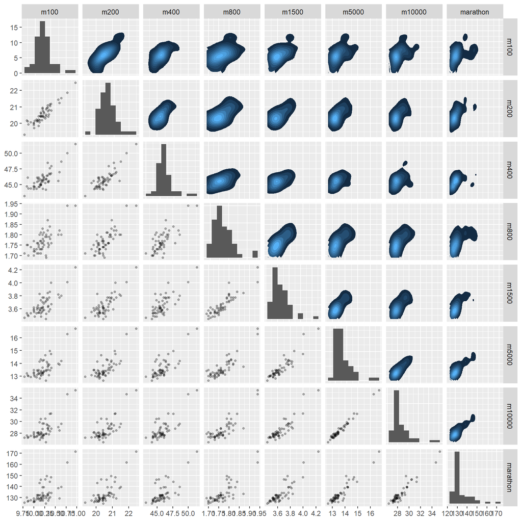

```r
GGally::ggpairs( track_records_dataset %>% select(-country),
                 diag = list(continuous = wrap("barDiag", bins=10) ),
                 upper = list(continuous = "density",
                              mapping = ggplot2::aes_string(fill = "..level..")
                             ),
                 lower = list(continuous = wrap("points", alpha = 0.3, size=1) )
                )
```

All of the variables (events) look very positively correlated, meaning that high performance in one event is a good predictor of high performance in any other event.

The univariate distribution of each event record is more Gaussian for shorter events, and increasingly long-tailed on the right as events become longer (the long right tail is populated by very badly-performing countries).

# Correlation plot

```r
corr_matrix <-
  track_records_dataset %>%
    select(-country) %>%
    cor() %>%
    round(., digits=2)

kable(corr_matrix)
```

[output not shown]

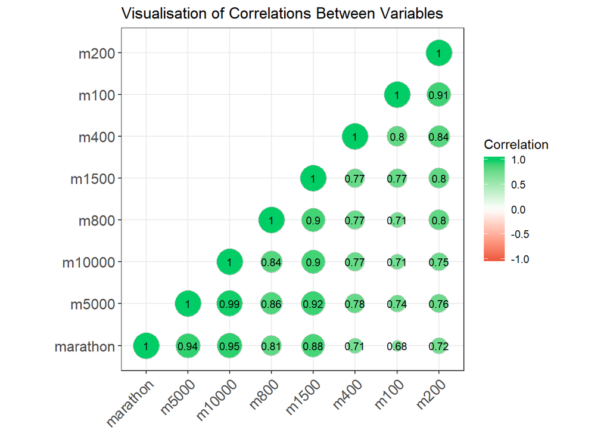

```r
ggcorrplot( corr = corr_matrix,               # correlation matrix to visualise
            type = "lower",         # only fill bottom diagonal
            ggtheme = theme_bw,     # simple theme for plot
            title = "Visualisation of Correlations Between Variables",
            show.legend = TRUE,
            show.diag = TRUE,
            legend.title = "Correlation",
            hc.order = TRUE,         # order the coefficients
            lab = TRUE,              # show correlation coefficients on the plot
            lab_size = 3,            # size of displayed coefficients
            method="circle",
            colors = c("tomato2", "white", "springgreen3")
          )
```

The variables are all positively correlated, meaning that countries with high performance in any one event are likely to be high-performers in any other event (and likewise for poorly performing countries).

The strongest correlations are between events with similar distances (e.g. short distance performance is strongly correlated with other short-distance event performance, and likewise long-distance event performance is strongly correlated with performance in other long-distance events).

# Best event by country

Now, event performances are reported by country, where each column of the data has been standardised (centred to have mean 0 and scaled to have standard deviation 1). This plot highlights whether each country is performing above or below the mean performance in each event.

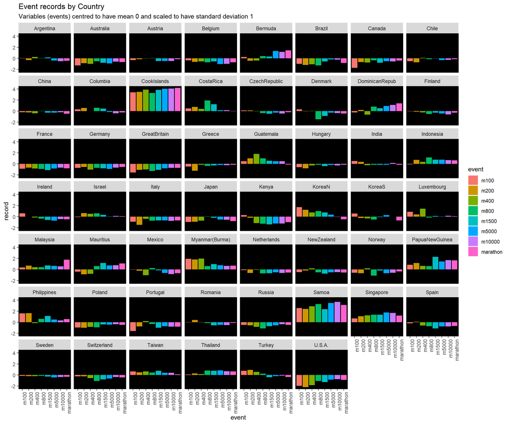

```r
track_records_dataset %>%
  mutate_if( is.numeric, scale) %>%
  gather( key="event", value="record", -country ) %>%
  mutate( event = factor(event,
                         levels = c("m100",
                                    "m200",
                                    "m400",
                                    "m800",
                                    "m1500",
                                    "m5000",
                                    "m10000",
                                    "marathon")
                         )
        ) %>%
ggplot( data = .,
        aes( x = event,
             y = record,
             fill = event
          )
     ) +
 geom_bar( stat="identity", position="dodge") +
 theme( axis.text.x = element_text(angle = 90, hjust = 1),
                 panel.background = element_rect(fill = "black",
                                colour = "black",
                                size = 0.5, linetype = "solid"),
                 panel.grid = element_blank()
      ) +
 facet_wrap( ~country ) +
 labs( title = "Event records by Country",
       subtitle = "Variables (events) centred to have mean 0 and scaled to have standard deviation 1"
     )
```

Cook Islands performs by far the worst across all events, followed closely in poor performance by Samoa.

U.S.A. is clearly the best in the short-distance events.

# Compare country performance by event

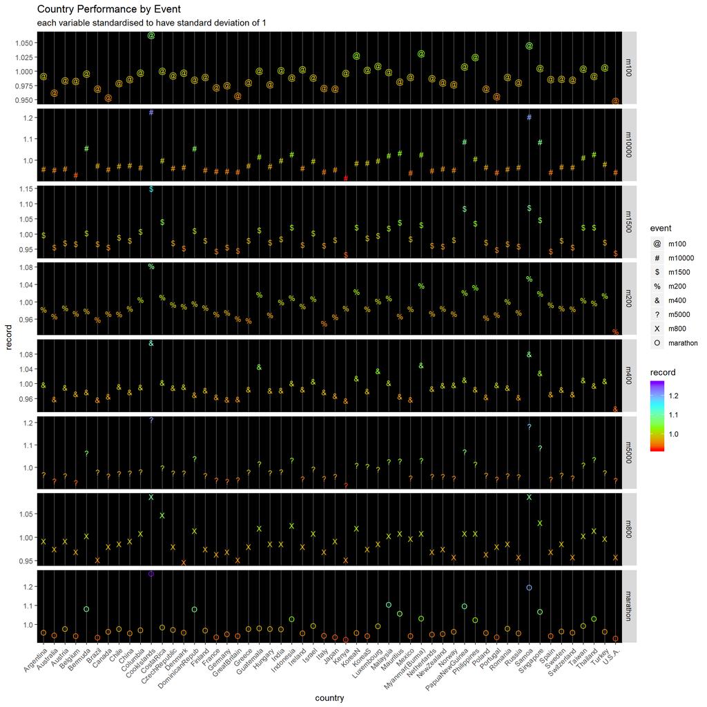

```r
track_records_dataset %>%
  mutate_if( is.numeric, scale, scale=TRUE, center=FALSE ) %>%
  gather( key="event", value="record", -country ) %>%
  ggplot( data = .,
          aes( x = country,
               y = record,
               colour = record,
               shape = event
             )
        ) +
  geom_point(size=3) +
  scale_colour_gradientn( colours = rainbow(4) ) +
  theme( axis.text.x = element_text(angle=45, hjust=1, vjust=1),
         panel.background = element_rect(fill = "black",
                                colour = "black",
                                size = 0.5, linetype = "solid"),
         panel.grid = element_blank()
         ) +
  scale_shape_manual( values = c("@","#","$","%","&","?","X","O") ) +
  facet_grid( event~., scale="free_y") +
  geom_vline( xintercept = 0:100, colour = "white", alpha=0.3 ) +
  labs( title = "Country Performance by Event",
        subtitle = "each variable standardised to have standard deviation of 1"
  )
```

# Event Rankings by Country

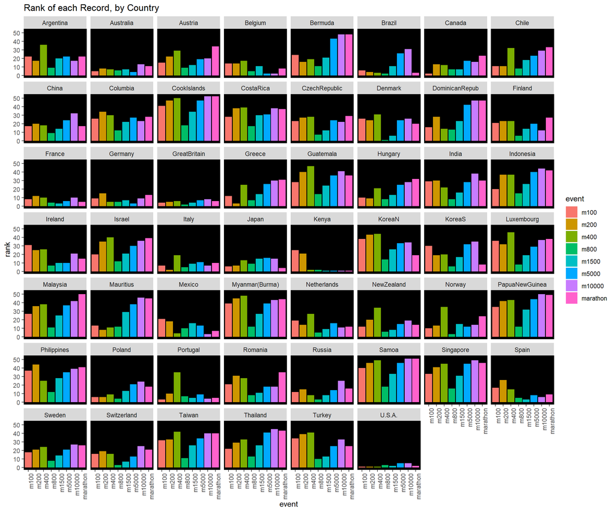

```r
track_records_dataset %>%
  mutate_if(is.numeric, dense_rank ) %>%
  gather( key="event", value="rank", -country ) %>%
  mutate( event = factor(event,
                       levels = c("m100",
                                  "m200",
                                  "m400",
                                  "m800",
                                  "m1500",
                                  "m5000",
                                  "m10000",
                                  "marathon")
                       )
        ) %>%
ggplot( data = .,
        aes( x = event,
             y = rank,
             fill = event
          )
     ) +
 geom_bar( stat="identity", position="dodge") +
 theme( axis.text.x = element_text(angle = 90, hjust = 1),
        panel.background = element_rect(fill = "black",
                  colour = "black",
                  size = 0.5, linetype = "solid"),
        panel.grid = element_blank()
      ) +
 facet_wrap( ~country ) +
 labs( title = "Rank of each Record, by Country" )
```